# Jan0809 OKCupid

Joseph Holler

2025-01-09

## Set up environment

Install tidyverse and here packages.  
This block has the `eval=FALSE` option so that installation does not automatically run.

```r
install.packages("tidyverse")
install.packages("here")
install.packages("tidytext")
install.packages("scales")
```

Load tidyverse and here packages.  
This block *does* run by default so that the knitting process has all the packages it needs. `include=false` prevents all the messages from package installation from being written in the document.

## Load OK Cupid Data

Set up path to store the data In Rmarkdown, a line with just a data object will print out that data object.

```r
if(!dir.exists(here("data_private"))) {dir.create(here("data_private"))}
# set file path
okCupidFilePath <- here("data_private", "profiles.csv")
# show the file path
okCupidFilePath
```

```
## [1] "D:/github/opengisci/wt25_josephholler/data_private/profiles.csv"
```

Download the file from https://geography.middlebury.edu/jholler/wt25/profiles.csv This block has `eval=FALSE` so that the file is only downloaded when the block is manually run

```r
if(!file.exists(okCupidFilePath)){
  download.file("https://geography.middlebury.edu/jholler/wt25/profiles.csv",
                okCupidFilePath)
}
```

use `read_csv` to load CSV files into R `file.choose()` allows you to interactively pick a file, but this is annoyingly not reproducible

```r
okcupid_data <- read_csv(file.choose())
```

Even better, use the `here` package for reproducible file paths

```r
okcupid_data <- read_csv(okCupidFilePath)
```

Save the OK Cupid data in R’s RDS data format

```r
cupidRDSpath <- here("data_private", "okCupid.RDS")
saveRDS(okcupid_data, cupidRDSpath)
```

Load the OK Cupid data from the RDS file

```r
loadedCupidData <- readRDS(cupidRDSpath)
```

Our first set of twitter data is available to you at https://geography.middlebury.edu/jholler/wt25/dorian/dorian_raw.RDS This data is both too large and too restricted to commit publicly. Keep it in the `data_private` folder

```r
loadedCupidData <- readRDS(cupidRDSpath)
```

# OK Cupid

## Height

What do people report their height as?

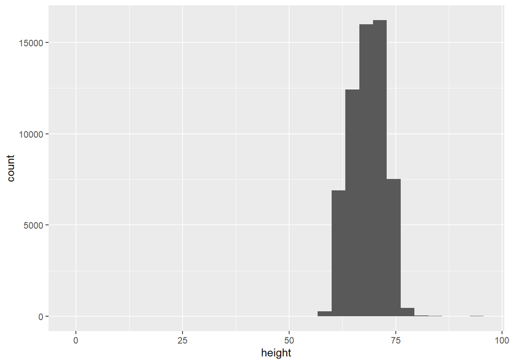

```r
okcupid_data |>
  ggplot() +
  geom_histogram(aes(x = height))
```

Clearly there are some inaccurate self-reported data in here, so lets’ restrict the range of the x-axis Tough decisions to make when graphing, so you need to find a balance in the data visualization goals and exclusion of some individuals from the data.

Switch to `geom_bar()` to make one bar for each integer value in a bar chart

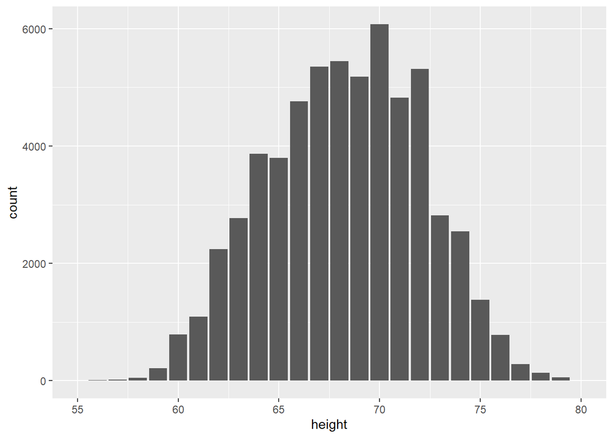

```r
okcupid_data |>
  ggplot() +
  geom_bar(aes(x = height)) +
  xlim(55, 80)
```

There are two different peaks for each gender’s mean, so let’s facet the graphs

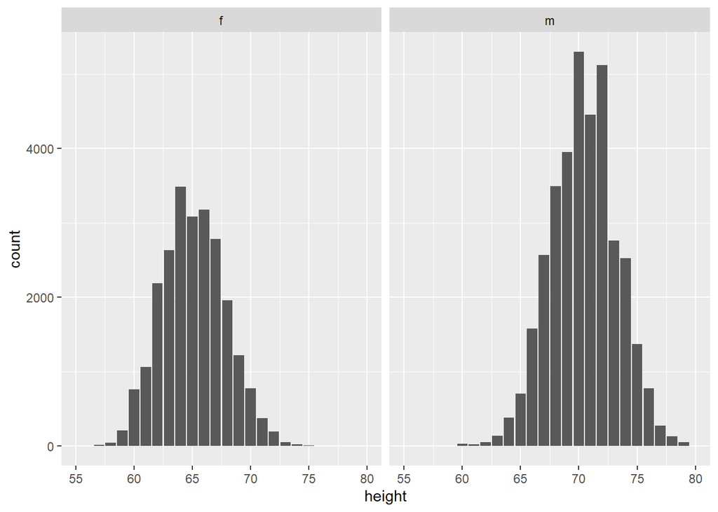

```r
okcupid_data |>
  ggplot() +
  geom_bar(aes(x = height)) +
  xlim(55, 80) +
  facet_wrap(~sex)
```

There are more men than women on OKCupid. There are spikes rounding up to appealing heights.

## Age

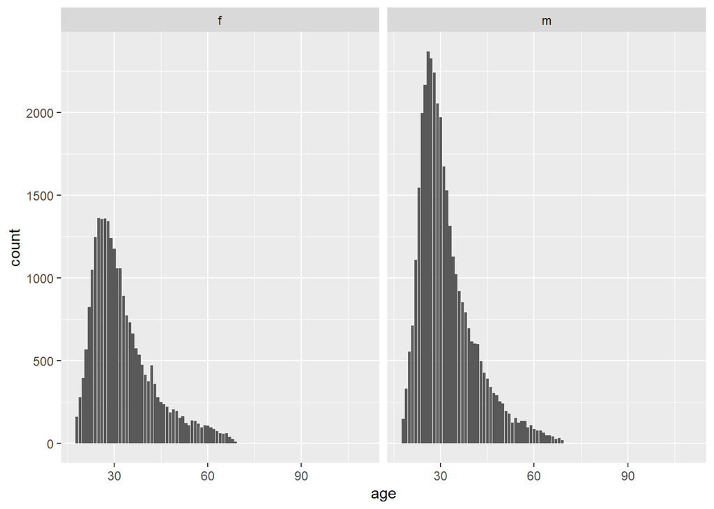

```r
okcupid_data |>
  ggplot() +
  geom_bar(aes(x = age)) +
  facet_wrap(~sex)
```

There are more men, but the distributions are very similar. How can we compare the two datasets to see if their patterns are similar? Try a density plot coded by color fill. Add transparency so that you can see. I would prefer to change the color (line) rather than the fill

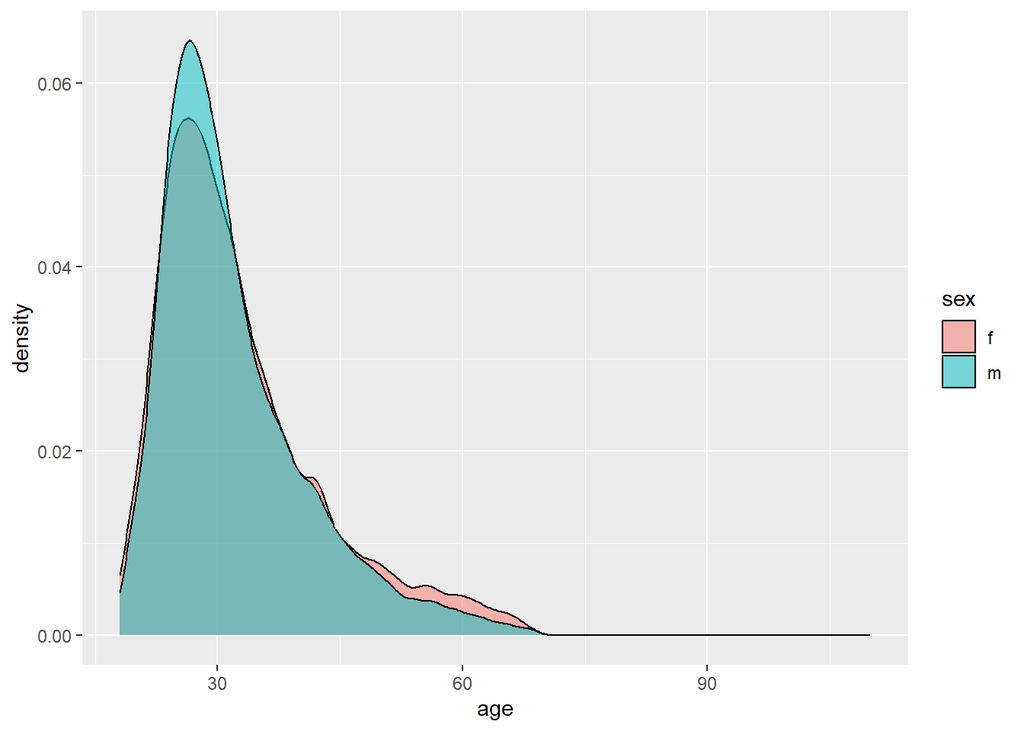

```r
okcupid_data |>
  ggplot() +
  geom_density(aes(x = age, fill = sex), alpha=0.5)
```

# Diet and Body Type

Count diet responses

```r
okcupid_data |>
  count(diet)
```

```
## # A tibble: 19 × 2
##    diet                    n
##    <chr>               <int>
##  1 anything             6183
##  2 halal                  11
##  3 kosher                 11
##  4 mostly anything     16585
##  5 mostly halal           48
##  6 mostly kosher          86
##  7 mostly other         1007
##  8 mostly vegan          338
##  9 mostly vegetarian    3444
## 10 other                 331
## 11 strictly anything    5113
## 12 strictly halal         18
## 13 strictly kosher        18
## 14 strictly other        452
## 15 strictly vegan        228
## 16 strictly vegetarian   875
## 17 vegan                 136
## 18 vegetarian            667
## 19 <NA>                24395
```

Count body type responses

```r
okcupid_data |>
  count(body_type)
```

```
## # A tibble: 13 × 2
##    body_type          n
##    <chr>          <int>
##  1 a little extra  2629
##  2 athletic       11819
##  3 average        14652
##  4 curvy           3924
##  5 fit            12711
##  6 full figured    1009
##  7 jacked           421
##  8 overweight       444
##  9 rather not say   198
## 10 skinny          1777
## 11 thin            4711
## 12 used up          355
## 13 <NA>            5296
```

We probably want to condense these categories to simplify graphing

### Collapse Diet Categories

Use `case_when` to switch (simplify) diet type values

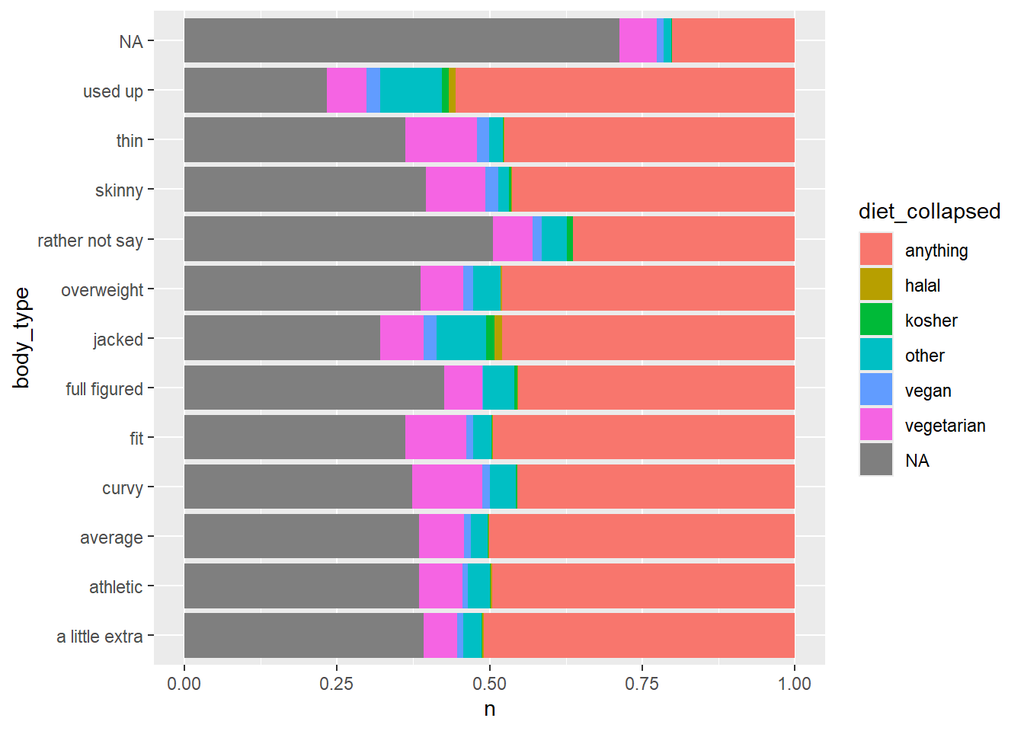

```r
okcupid_data |>
  mutate(diet_collapsed = case_when(str_detect(diet, "halal") ~ "halal",
                                    str_detect(diet, "kosher") ~ "kosher",
                                    str_detect(diet, "other") ~ "other",
                                    str_detect(diet, "vegan") ~ "vegan",
                                    str_detect(diet, "anything") ~ "anything",
                                    str_detect(diet, "vegetarian") ~ "vegetarian")) |>
  count(diet_collapsed, body_type) |>
  ggplot() +
  geom_col(aes(y = body_type, x = n, fill = diet_collapsed), position = "fill")
```

# Save dataset to computer

First save a data object in the environment

```r
okcupid_data_with_diet_collapsed <- okcupid_data |>
  mutate(diet_collapsed = case_when(str_detect(diet, "halal") ~ "halal",
                                    str_detect(diet, "kosher") ~ "kosher",
                                    str_detect(diet, "other") ~ "other",
                                    str_detect(diet, "vegan") ~ "vegan",
                                    str_detect(diet, "anything") ~ "anything",
                                    str_detect(diet, "vegetarian") ~ "vegetarian"))
```

Then save to a CSV file. By default, this woudl save to the working directory. The working directory can be changed with session -> set working directory.  
However, an even better solution is to use the `here` package

```r
write_csv(okcupid_data_with_diet_collapsed,
          here("data_private", "okcupid_with_diet_collapsed.csv"))
```

# regraph diet / body type as heat map

We can change the scale of fill

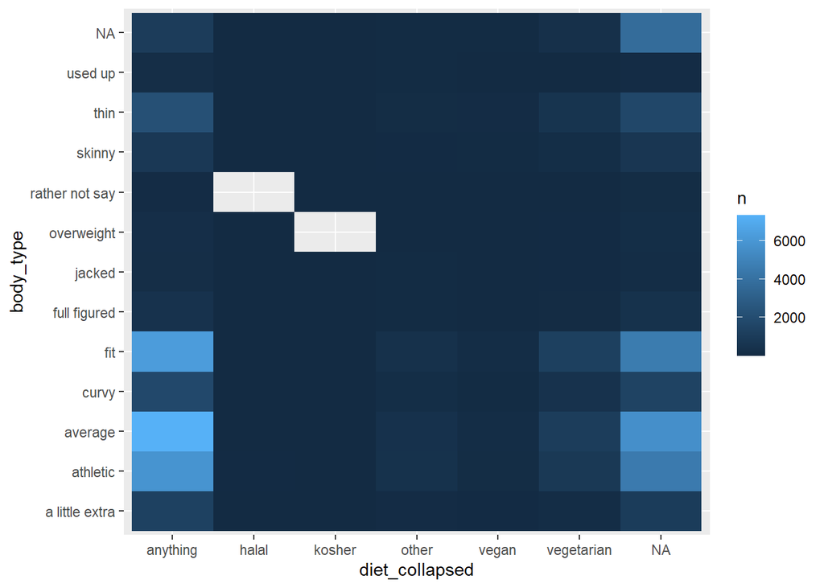

```r
okcupid_data_with_diet_collapsed |>
  count(diet_collapsed, body_type) |>
  ggplot() +
  geom_tile(aes(x = diet_collapsed, y = body_type, fill = n))
```

# log transform a variable so it looks better on graph

This was added on January 13, including addition to `scales` library up

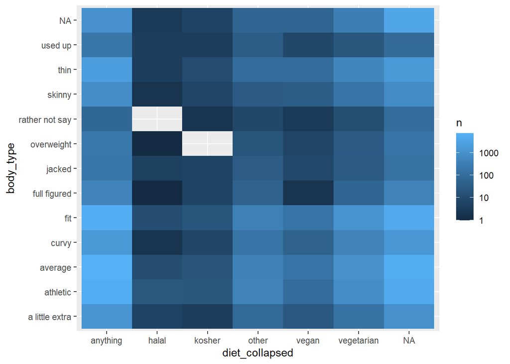

```r
okcupid_data_with_diet_collapsed |>
  count(diet_collapsed, body_type) |>
  ggplot() +
  geom_tile(aes(x = diet_collapsed, y = body_type, fill = n)) +
  scale_fill_gradient(trans = log10_trans())
```

# Text mining

- anonymize the data
- consider ethics / legality of reposting and how to repost

## Essay data dictionary

| Variable | Description |
| --- | --- |
| essay0 | My self summary |
| essay1 | What I’m doing with my life |
| essay2 | I’m really good at |
| essay3 | The first thing people usually notice about me |
| essay4 | Favorite books, movies, show, music, and food |
| essay5 | The six things I could never do without |
| essay6 | I spend a lot of time thinking about |
| essay7 | On a typical Friday night I am |
| essay8 | The most private thing I am willing to admit |
| essay9 | You should message me if… |

## What are people really good at?

This is stored in essay2 Let’s look at a few responses With markdown, you can keep re-running the cell

```r
okcupid_data |>
  sample_n(1) |>
  pull(essay2)
```

```
## [1] NA
```

Let’s scale up the text analysis

How many people are good at sports? `str_detect` searches for a text string  
including `|` means `or`

```r
okcupid_data |>
  mutate(is_good_at_sports = str_detect(essay2, "sports|soccer|baseball|football|basketball")) |>
  count(is_good_at_sports)
```

```
## # A tibble: 3 × 2
##   is_good_at_sports     n
##   <lgl>             <int>
## 1 FALSE             47737
## 2 TRUE               2571
## 3 NA                 9638
```

What is the relationship between body type and people who say they are good at sports?

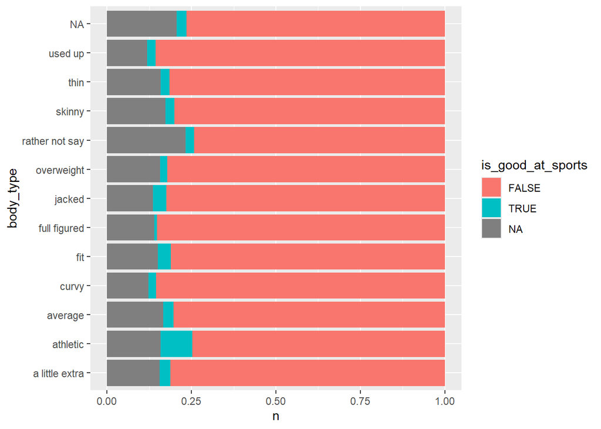

```r
okcupid_data |>
  mutate(is_good_at_sports = str_detect(essay2, "sports|soccer|baseball|football|basketball")) |>
  count(is_good_at_sports, body_type) |>
  ggplot() +
  geom_col(aes(y = body_type, x = n, fill = is_good_at_sports), position = "fill")
```

Remove the missing data with `filter(!is.na(essay2))`

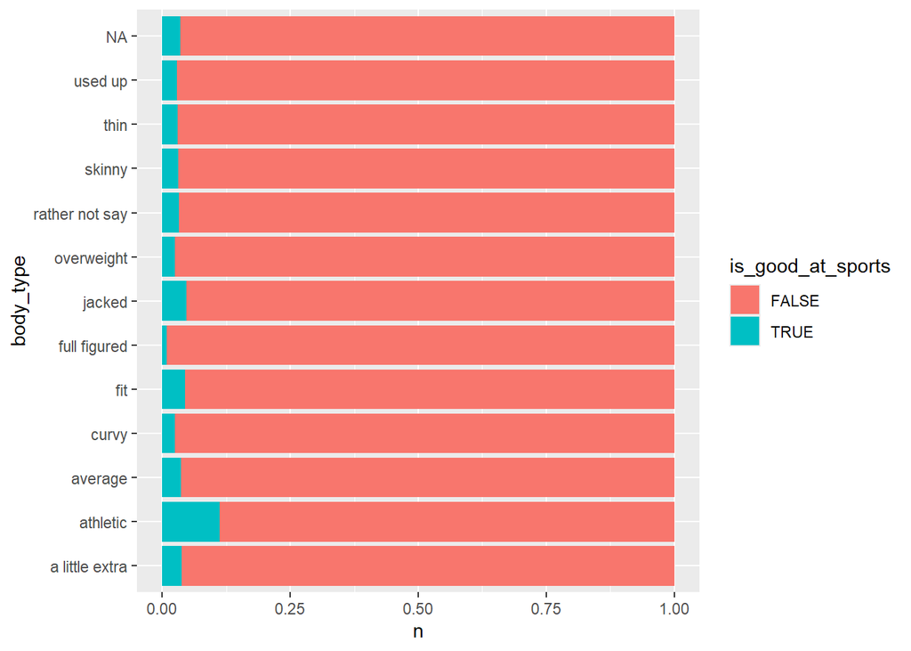

```r
okcupid_data |>
  mutate(is_good_at_sports = str_detect(essay2, "sports|soccer|baseball|football|basketball")) |>
  filter(!is.na(essay2)) |>
  count(is_good_at_sports, body_type) |>
  ggplot() +
  geom_col(aes(y = body_type, x = n, fill = is_good_at_sports), position = "fill")
```

People who say they’re athletic or jacked are more likely to say they’re good at some sport

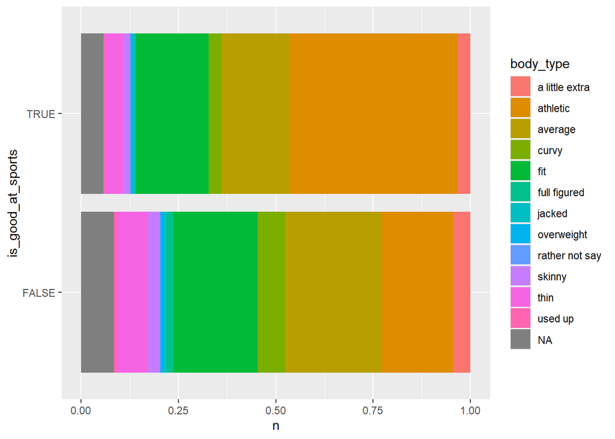

```r
okcupid_data |>
  mutate(is_good_at_sports = str_detect(essay2, "sports|soccer|baseball|football|basketball")) |>
  filter(!is.na(essay2)) |>
  count(is_good_at_sports, body_type) |>
  ggplot() +
  geom_col(aes(y = is_good_at_sports, x = n, fill = body_type), position = "fill")
```

A large proportion of the folks who mentioned being good at a sport thought they had an athletic body type

## Analyze word usage in essays

```r
okcupid_data |>
  unnest_tokens(input = essay2,
                output = "word") |>
  count(word)
```

```
## # A tibble: 33,810 × 2
##    word       n
##    <chr>  <int>
##  1 0         41
##  2 0.13       1
##  3 0.334      1
##  4 0.99       1
##  5 00         6
##  6 000000     1
##  7 007        2
##  8 00am       1
##  9 00s        2
## 10 00t        1
## # ℹ 33,800 more rows
```

Let’s arrange the dataset to sort by n Also filter by stop_words

```r
essay2word_counts <-
  okcupid_data |>
  unnest_tokens(input = essay2,
                output = "word",
                format = "html") |>
  count(word) |>
  arrange(-n) |>
  filter(!(word %in% stop_words$word))

essay2word_counts
```

```
## # A tibble: 31,253 × 2
##    word          n
##    <chr>     <int>
##  1 people    15118
##  2 cooking    7042
##  3 listening  6497
##  4 laugh      4776
##  5 love       4400
##  6 friends    3961
##  7 time       3899
##  8 pretty     3368
##  9 finding    3322
## 10 playing    3157
## # ℹ 31,243 more rows
```

Interestingly, I’m getting results of conjunctions because I used the html filter, but those could be filtered out as well.

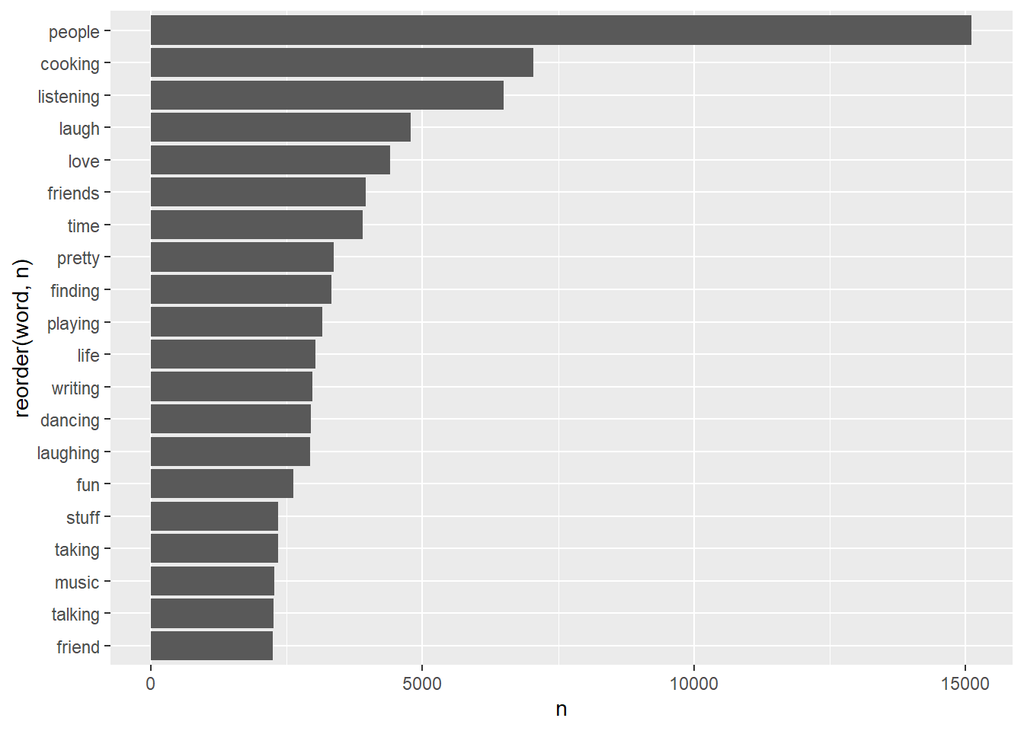

```r
essay2word_counts |>
  filter(!(word %in% c("br", "href", "ilink", "ve", "don")),
           !is.na(word)) |>
  head(20) |>
  ggplot() +
  geom_col(aes(y= reorder(word, n), x = n))
```

Try again with essay 8

```r
essay8word_counts <-
  okcupid_data |>
  unnest_tokens(input = essay8,
                output = "word") |>
  count(word) |>
  arrange(-n) |>
  filter(!(word %in% stop_words$word))

essay8word_counts
```

```
## # A tibble: 29,012 × 2
##    word        n
##    <chr>   <int>
##  1 <NA>    19214
##  2 br      16439
##  3 private  3858
##  4 love     2958
##  5 people   2420
##  6 time     2095
##  7 admit    1687
##  8 person   1656
##  9 life     1488
## 10 pretty   1480
## # ℹ 29,002 more rows
```

This time, do it the same way as shown, without altering the mode.

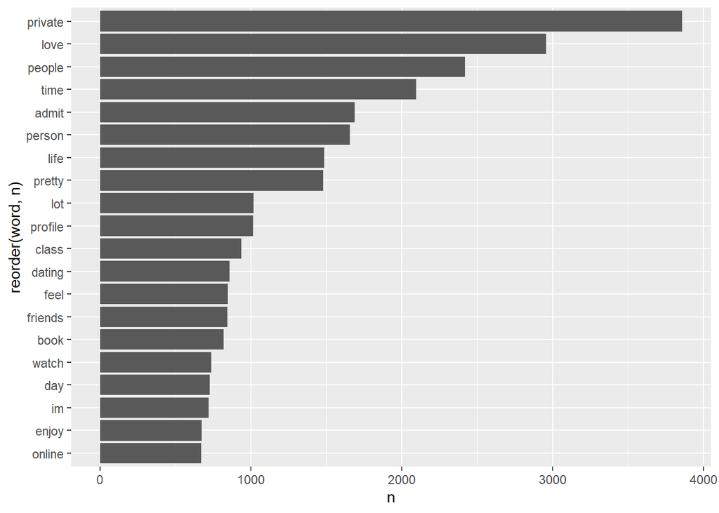

```r
essay8word_counts |>
  filter(!(word %in% c("br", "href", "ilink")),
           !is.na(word)) |>
  head(20) |>
  ggplot() +
  geom_col(aes(y= reorder(word, n), x = n))
```

This Rmd did not initially knit without separate installation of `hunspell` package.